# Shockwave

When a body collides with another body, the impact often causes some displacement due to changes in volume. This is seen when a rock is thrown into a lake and causes ripples to move outwards; or when you press jelly with a spoon. When the meteor that killed the dinosaurs crashed into the Earth’s surface, it probably caused a shockwave as well.

[video not shown]

The shockwave, or ripple, effect simulates this effect. We can use it for explosions, stomps, earth bending skills, ripples in a water body, and much more.

In this tutorial, you’re going to learn some essential visual effects skills that you can apply to other shaders arts:

- Create dynamic masks
- Render secondary viewports
- Combine textures using shaders
- Manipulate texture UV map

## Setup the scene

For our effect we’re going to use an unusual scene setup. We’ll take the game screen, process it, apply the effect, and finally render the game screen with the effect.

We have our game world where the actual game happens, and we have our “post process” layer which takes the game world and applies our effect on top of it. This is a common layout when you work with screen space shaders.

Let’s add a new *Node* as the root of our scene. This is the node that holds the necessary setup for our effect to work. Let’s call it “Game”.

Add a new *Texture Rect* as a child. Here’s where the magic happens. Rename it as *PostProcessedScreen* and in the Layout menu, select “Full Rect” so it takes up the whole screen. We’ll use this node to display the game’s world after we have applied our effect.

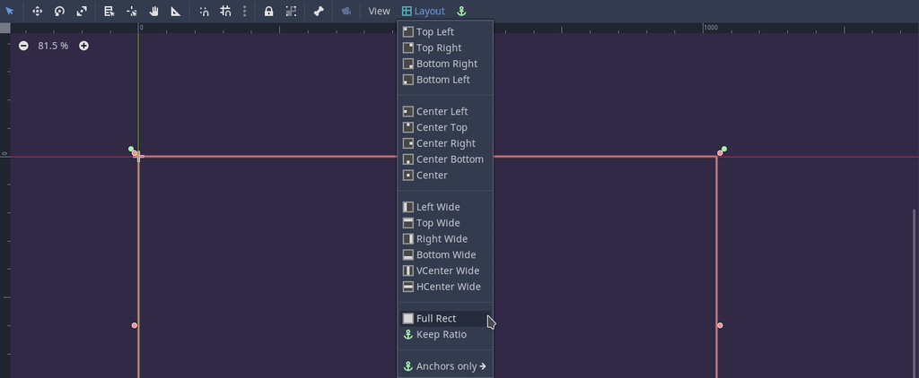

We’ll pass snapshots of the raw game screen to the *Texture* property and then apply the shader to it. The final result will be our post processed screen so this node holds our shader.

In the *Shockwave/* folder, drag the *displacement_material.tres* to the *PostProcessedScreen > material* slot. It’s a simple CanvasMaterial that uses our *displacement_shader* which we prepared beforehand.

[video not shown]

Ensure that the *displacement_material.tres* is marked as *local_to_scene* to avoid changing anything outside of this scene which shares this resource.

Let’s look at how the *displacement_shader* works.

## The distortion shader

Distortion shaders, also know as displacement shaders, work by remapping a texture by changing its UV coordinates.

If you want to know how this UV mapping works, you can watch [Part 2](https://www.youtube.com/watch?v=U91nqeUe1qQ) of our video series introducing shaders, where Nathan talks about manipulating UV maps.

To get in depth knowledge and learn the secrets of the shaders arts check out our [Shader Secrets course](https://gdquest.mavenseed.com/courses/shader-secrets-learn-to-code-2d-and-3d-shaders-in-godot), where François guides you through the ins and outs of this *shady* art.

In our distortion shader, we use a texture to dictate how the UV coordinates will be displaced.

```
shader_type canvas_item;

uniform sampler2D displacement_mask;
uniform float displacement_amount = 5.0;
```

Then, we take the object’s current texture and remap it using the new displaced UV.

```
void fragment() {
    float uv_displace_amount = displacement_amount * 1.0 / float(textureSize(TEXTURE, 0).x);
    vec4 displacement = texture(displacement_mask, UV);
    vec2 displacement_uv = UV + displacement.xy * uv_displace_amount;
    COLOR = texture(TEXTURE, displacement_uv);
}
```

Let’s see how we can feed the shader with these two textures so it can do its magic.

## Feeding the shader

Our shader is pretty agnostic with the textures it uses, so we can pass anything to it and it’ll do its job. But since we’re aiming for a **shockwave** effect, we need these textures to be dynamic since the wave will move and dissipate.

Instead of passing pre-rendered images to the shader, we’ll pass snapshots of how the game is at a given moment using Viewport Textures.

In Godot, a Viewport processes all its children and renders a texture which represents our game. For instance, if you add two Sprites as children of a Viewport, it renders a canvas with a background and those two Sprites.

If you run a scene and check the “Remote” view of the SceneTree, you’ll notice there’s a node of type Viewport called *root*. This is the ultimate Viewport that Godot uses to render everything else.

[video not shown]

For our shader we’ll add two Viewports to our scene. The idea is that each Viewport renders two different worlds that we’ll mix later with our shader.

The first Viewport is going to render our game world, so let’s call it “World”. Everything that is part of our game boils down to this Viewport.

Let’s call the second Viewport *Mask*. We’ll use everything it renders as a mask which is used in the shader.

We’ve set up a basic scene that you can use to test this effect. In the *Shockwave/* folder drag the *ShockwaveWorld.tscn* to the SceneTree as a child of the *World* node.

[video not shown]

Notice that as soon as we add the *ShockwaveWorld* as a child of the *World* Viewport, it disappears. This is because a custom Viewport needs a render target to display what it rendered. Godot uses the game’s window as a render target for the *root* Viewport, but for custom Viewports we have to create render targets manually. Here is where our *PostProcessedScreen* comes in. We’ll use it to render our *World*.

Remember, since Godot’s SceneTree processes nodes from top to bottom and, since our Viewports are dependencies of the *PostProcessedScreen*, they need to be processed before the *PostProcessedScreen* can use them. So we need to move the *PostProcessedScreen* to the bottom of the hierarchy.

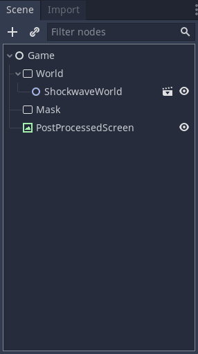

Before we can render our custom Viewports, we need to define their capture rectangle.

Hold shift to select both the *World* and the *Mask* nodes and in the Inspector. In our case, both Viewports are going to take the full screen. So in the *Size* property let’s make the `x` and `y` values match our game’s window width and height respectively. Set `x` to `1024` and `y` to `600`.

Let’s also ensure that they render with transparent backgrounds so we can properly mix them in the shader. Mark the *Transparent BG* property as true.

If there isn’t an update in a Viewport or if the Viewport is not visible, Godot doesn’t process it for optimization reasons. In our case they won’t be visible directly, but we still want to process them. So let’s ensure that both our Viewports are always processing by forcing them to always update. In the *Render Target > Update Mode* left-click where it says “When Visible” and from the dropdown menu select “Always”.

Since we’re using custom Viewports, we have to manually tell them to flip their rendered texture vertically. Otherwise we get a mirrored version of our game in our *PostProcessedScreen*. Turn the *Render Target > V Flip* option as true.

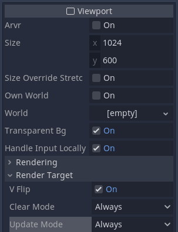

With that we can render them to our render target! Select the *PostProcessedScreen* and in the *Texture* property left-click the “Empty” slot. From the dropdown menu select “New Viewport Texture” and from the popup menu, select the *World* Viewport. Now we can see our *ShockwaveWorld*!

[video not shown]

If you look closely you can notice that our *World* looks sharp, which may not reflect how the *ShockwaveWorld* looks. This is because it became a texture and it we didn’t tell Godot to apply the proper filters to this new texture. Let’s fix this.

*Note that this step isn’t necessary if you want sharp edges in your game. For instance, if you’re going with a pixel art aesthetic you can skip this fix.*

Left-click on the *PostProcessedScreen > Texture* slot to edit this resource. In the *Flags* category check the *Mipmaps* and the *Filter* options and voila, our *World* is fixed.

[video not shown]

Next, let’s setup our *Mask* render target which is the *displacement_shader > Displacement Mask* parameter. Left-click the *PostProcessedScreen > Material > Material* to display the *Shader Param* category. Left-click the *Displacement Mask* slot and create a new Viewport Texture. This time, select the *Mask* Viewport from the popup menu.

If you get the following popup instead, right-click the *displacement_material* slot and select “Make Unique”. This happens due to Viewport Textures having a dependency on the hierarchy of the scene so they can only be saved as built-in resources of a PackedScene.

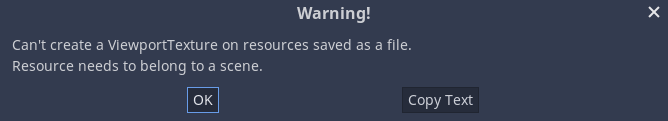

[video not shown]

You can repeat the filtering fix that we used in the *World* Viewport Texture to get a smoother result for the *Mask* Viewport Texture as well.

Now, anything the *Mask* draws results in a distortion. As a test, you can drag the *white_ring.png* image from the *Assets/* folder and drop it on top of our little planet. Make sure it instances as a child of the *Mask* Viewport.

[video not shown]

In this chapter we’ve talked a lot about Viewports and Viewport Textures. If you’re still unsure, the [official documentation](https://docs.godotengine.org/en/stable/tutorials/viewports/viewports.html) is highly recommended so you can better understand them.

We have our mask working! It’s time to design our shockwave.

## The shockwave

Let’s create a new scene to focus on the effect itself.

We’re going to use a *Particles2D* for the shockwave to procedurally animate the wave, but you can use a *Sprite* instead if you want more control. Add a new *Particles2D* to the scene and rename it to *Shockwave*.

Drag the *white_ring.png* image from the *Assets/* folder to the *Shockwave > Texture* slot. This represents our shockwave.

The *Amount* property dictates how many shockwaves the effect produces along its *Lifetime*. For instance, if we want an effect that resembles ripples on the water, we can increase the *Amount* to `8` or `10`.

Our shockwave is caused by a meteor and, since the Earth is very solid, we’ll set the *Amount* to `3`. To slowdown the particles, increase the *Lifetime* to `2.0` seconds.

If you want to use this effect in moving objects, you’ll also need to uncheck the *Drawing > Local Coords* property. This is useful if you have a ship moving on water that creates ripples, or a spaceship that activates a boost. This is what we did in our game, Harvester.

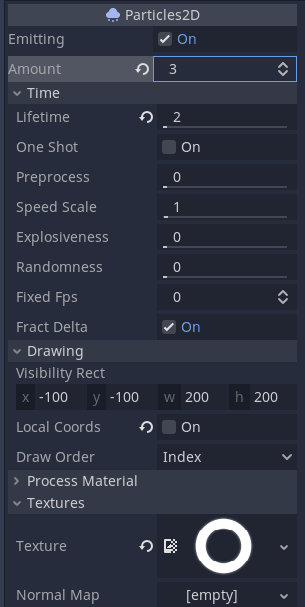

In the *Process Material > Material* property create a new *Particles Material*. We’ll use this to animate the shockwave.

To prevent the rings from falling, disable the gravity of the *Particles Material* by setting all three values to `0` in *Gravity > Gravity*.

A shockwave grows in size quickly then suddenly stops. Check out [Riot’s Game video about explosions timing](https://youtu.be/3QKK2o5rWSQ?t=457) for more details and examples.

To mimic this behavior we’ll use scale curves. In the *Scale > Scale Curve* property, create a new CurveTexture. Left-click the CurveTexture and the *Curve* slot to edit the curve. Right-click on the graph and from the dropdown menu go to *Load Preset > Ease Out*.

We need to tweak the preset a bit to achieve the result we want.

Left-click on the point on the left and adjust its handle to increase the curvature to make it look like a hill. Fine tune the point on the right as well. Depending on your final composition you may also want to tweak the final scale of the effect as well. In our case, we’ll scale it up. Set the *Scale > Scale* property to `5.0`.

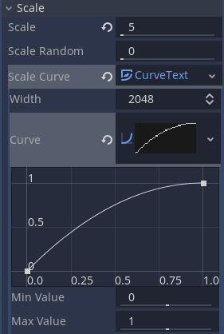

The displacement should also gradually lose its strength as the shockwave grows in size. We can achieve this by fading out.

In the *Color > Color Ramp* property create a new Gradient Texture and make a Gradient which starts with full opaque white and ends with full transparent white. The fading should only happen towards the end of the Gradient.

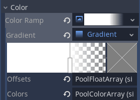

At this point we can save our *Shockwave* scene to make it a reusable asset.

## Applying the effect

Now that we have our scene ready and our effect done, we can apply it to our final composition.

Create an instance of the *Shockwave* in our *Game* scene and position it accordingly. With the effect in place, we’ll reparent it as a child of the *Mask* Viewport.

[video not shown]

And there we have it! You can use an *AnimationPlayer* to trigger the *Shockwave > Emitting* property, or even a *Timer*.

In the *ShockwaveDemo*, we’ve played a bit with the *Shockwave > Speed Scale* by decreasing it to `0.8` to give more weight to the comet’s impact, but that’s optional.

You can also play with the *PostProcessedScreen > Material > Displacement Amount* to change the strength of the effect. We’ve set it to `8` in the *ShockwaveDemo*.

Note that this is a static implementation of this effect. Ideally, the *Mask* node would dynamically instance the *Shockwave* triggered by some event. You can apply our [*EventBus design pattern*](https://www.gdquest.com/docs/guidelines/best-practices/godot-gdscript/event-bus/) to make the communication between the trigger and the *Mask*. For example, we could make the *Explosion* emit a signal that would prompt the *Mask* to add a *Shockwave* at the *Explosion* position.